# Exploratory visualization on Iris

# Preview of all data

## Preview scatters

Unlike other languages,a tutorial of R would start by demonstrating how to make a rather sophisticated plot of the iris dataset instread of printing “Hello World!”.

Let’s do it.

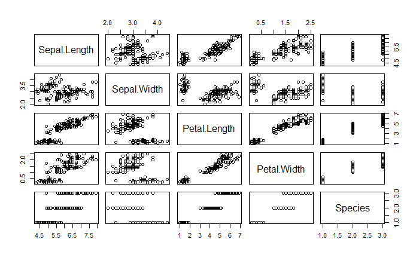

```r
plot(iris)
```

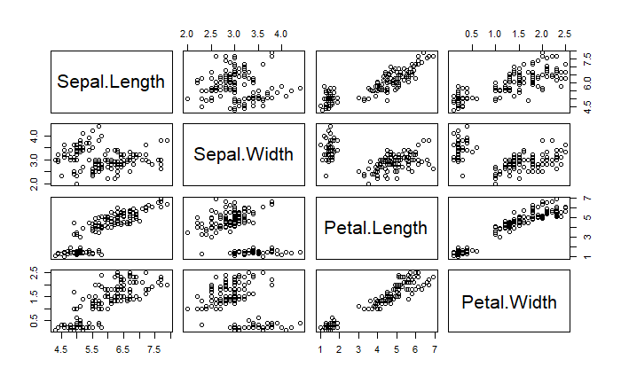

```r
plot(iris[,1:4])
```

The first plot made no sence of scattering the “Species” variable. In a non-jittered scatterplot, only numerical variable with separate locations are well-presented (they can lie sometimes!). Filter them out!

For modernized graphic, not only the correctness but also effect of presentation, ergonomic aesthetical aspects, interactivity, performance… should be taken into account. You possibly won’t get a good insight of data/ model/ relationship at once, but you can explore a bunch of recipes and customize for your own graphical discovery.

Talk is easy. The plot above is still no good, different subspecies are mixed together. Thanks to one of the inventions from the Bell’s Laboratory, we can use lattice library to quickly produce a number of plots in a better way.

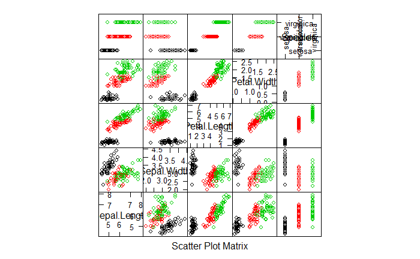

```r
library(lattice)
splom(iris,col = iris$Species)
```

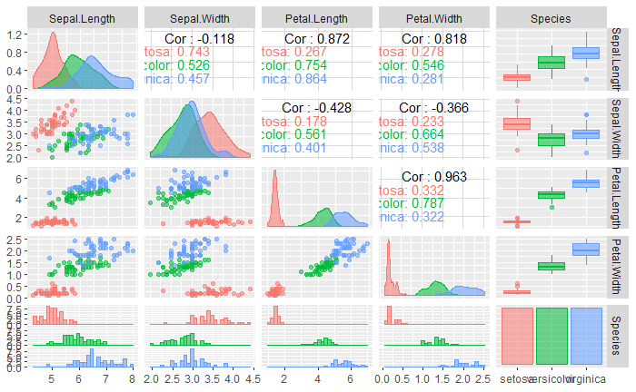

```r
library(ggplot2)
library(GGally)
GGally::ggpairs(iris,aes(fill = Species,color=Species,alpha=.5))
```

They are all maybe too complicated to look at for the first glance. I would recommend that you render them in a big screen and see some general patterns before starting to work on specific aspects.

For a more sophisticated first glance, see below.

### Preview Mapping?

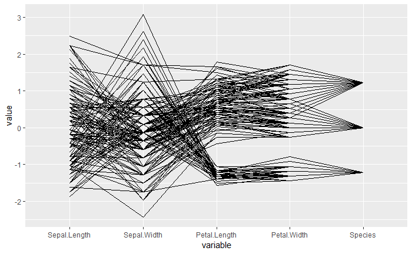

```r
#ggpairs(iris)
ggparcoord(iris)
```

and you can add more aspects, but tuning these recepies gets harder and more counter-intuitive.

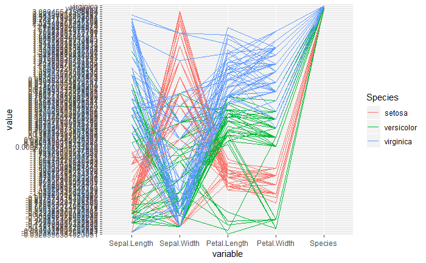

```r
ggparcoord(iris,groupColumn = 5)
```

And however you tune it, the plot is only suitable for previewing.

### Look up case 1: 1 var scatter plot

I would suggest setosa has thinner and shorter Petals? Actually you can plot those 2 variables easily:

either

```r
with(iris,{plot(Petal.Width~Petal.Length,col=factor(Species))})
```

[output not shown]

or (with ggplot2),

```r
ggplot2::qplot(data=iris,x = Petal.Length,y = Petal.Width,color= Species,geom ="point")
```

[output not shown]

Too “packagy”? Well, congratulations! 2 of the most popular packages in R for visualization is masters.

Well, does ggplot make any difference?

Hum, yes and no… let’s look at some compared examples:

```r
#first, define a graph object g, containing nothing but the data

g = ggplot(data = iris,aes(x = Petal.Length,y = Petal.Width))

#create a plot with colored scatters AND differen point types

g1 = g + geom_point(aes(color = Species,shape= Species))
g1

#now add some rugs

g1 = g1+ geom_rug(alpha = .5)# add transparency

g1

#now, group them

g1 = g1+ facet_grid(.~Species)

g1

#now, try applying a linear model to all
g1+ geom_smooth(method = 'lm')


#or maybe a lazy lowess curve for smoothing?

g1+geom_smooth()
```

[output not shown]

Pretty cool eh?

## Preview distributions?

What if I am a huge fan of subsetting the data and group them? well, of course I can subset the data, and divide them, and… wait a minute. There are lots of handy tools already defined!

```r
lattice::bwplot(Petal.Width ~ Species,iris)
```

[output not shown]

Equivalent to

```r
ggplot2::ggplot(data=iris,aes(y=Petal.Width,group = Species,color = Species))+geom_boxplot()+geom_rug(alpha=.5)
```

[output not shown]

And multi-variable histogram, consider: which is better below?

```r
ggplot(data=iris,aes(x=Petal.Length,fill = Species)) +
  geom_histogram(position = 'dodge')

ggplot(data=iris,aes(x=Petal.Length,fill = Species)) +
  geom_histogram(position = 'stack')
ggplot(data=iris,aes(x=Petal.Length,fill = Species)) +
  geom_histogram(position = 'identity',alpha=.5)
```

[output not shown]

Here’s the trick, when data may overlay, make jitter or transparency. Well, they make plotting slower for big data, but they stop graphs from lying.

For the same reason, try make a compared density plot.

```r
ggplot(data=iris,aes(x=Petal.Length,fill = Species)) +
  geom_density(alpha=.5)
```

[output not shown]

## Preview correlations?

What if I am a huge fan of combining linear models? An introduced way is to get the linear correlation coefficients (regardless what type).

```r
cor(iris[1:4])
```

[output not shown]

But it never makes sense. Can we use it symbolically?

```r
symnum(cor(iris[,1:4]))
```

[output not shown]

Yeah? Petal.Length and Petal.Width are good friends? Wait a minute, there are clever ways of doing it.

```r
corrplot::corrplot(cor(iris[,1:4]))
```

[output not shown]

And what? There’s a ggplot version?

```r
library(ggcorrplot)
library(RColorBrewer)
ggcorrplot(cor(iris[1:4]),method='circle',color =c("blue","purple","red"))
```

[output not shown]

## Preview higher dimension

What most tutorials do not mention is the 3D perspective plotting option. Reasons, or in other words, excuses, are that they are “misleading” and “time-consuming”.

Making good 3D plot is hard, but worth-trying sometimes.

The use of a package called plot3D will be demonstrated. It is one of the packages associated with r - GL ecosystem. The package plot3Drgl is a rgl version of plot3d package.

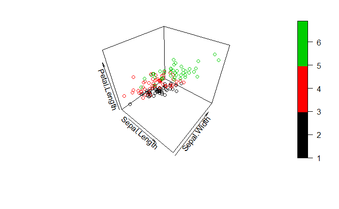

If, from one view, the plots seem to lay densely around a line, then the distribution may be any subsets of a plane. Change the angle phi and theta.

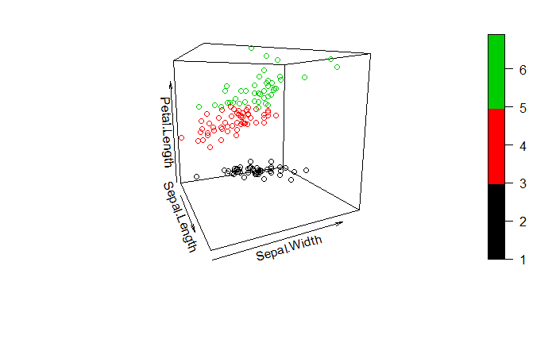

# Rethinking: How should we plot?

For years there are arguments on how plots should be made, there are people using rgl, lattice, ggplot, and lots and lots of alternatives. No graphic package is perfect for any situations at least so far.

It seems to me, the pros and cons of these devices are: